# Proyecto final

Sonia Yagüe Ruiz-Crespo

18/11/2019

# INTRODUCCIÓN

Para este proyecto final se van a desarrollar tres partes:

1. Compararación de los puntos de vista de [rpubs](http://rpubs.com/ydmarinb/429756) y [ub.edu](http://www.ub.edu/stat/docencia/Cursos-R/Radvanced/materials/CadenasenR.pdf) sobre expresiones regulares.
2. Comparación de los puntos de vista de [guides.github](https://guides.github.com/features/mastering-markdown/) y [markdownguide](https://www.markdownguide.org/getting-started/) sobre markdown.
3. Análisis de datos.

# EXPRESIONES REGULARES

## Página web 1

Las **expresiones regulares**, también conocidas como *regex*, *regexp* o *expresión racional*, es una secuencia de caracteres que forma un patrón de búsqueda, principalmente utilizada para la búsqueda de patrones de cadenas de caracteres u operaciones de sustituciones, como indica [rpubs](http://rpubs.com/ydmarinb/429756). Las expresiones regulares se construyen utilizando los operadores **unión, concatenación y clausura de Kleene**.

## Página web 2

La explicación de qué son las **expresiones regulares** es muy parecida según [ub.edu](http://www.ub.edu/stat/docencia/Cursos-R/Radvanced/materials/CadenasenR.pdf), según esta página web también suelen llamarse *regex* o *regexp* pues es una abreviación. Se trata de un lenguaje para poder definir exactamente lo que queremos buscar o reemplazar.

A diferencia de otros lenguajes, en los que las **expresiones regulares** se encierran entre algun tipo especial de delimitadores (por ejemplo entre “/”) en una **expresión regular** se representa como una cadena de texto. Existen tres tipos de **expresiones regulares**:

1. Expresiones regulares POSIX extendidas
2. Expresiones regulares básicas
3. Expresiones regulares de Perlu

# MARKDOWN

## Página web 1

[guides.github](https://guides.github.com/features/mastering-markdown/) define **markdown** como una forma de diseñar texto en la web. Pudiendo controla la visualización del documento, formatear palabras en negrita o cursiva, agregar imágenes y crear listas todo ello son solo algunas de las cosas que podemos hacer con **markdown**. Principalmente, Markdown es solo texto normal con algunos caracteres no alfabéticos, como *“#”* ó "*" .

## Página web 2

**Markdown** es un lenguaje de marcado ligero que puede usar para agregar elementos de formato a documentos de texto sin formato. Como bien define [markdownguide](https://www.markdownguide.org/getting-started/), **markdown** fue creado por *John Gruber* en 2004, **markdown** es ahora uno de los lenguajes de marcado más populares del mundo.

Usar Markdown es diferente de usar un editor *WYSIWYG* . En una aplicación como Microsoft Word, hace clic en los botones para formatear palabras y frases, y los cambios son visibles de inmediato. **Markdown** no es así. Cuando crea un archivo con formato **Markdown**, agrega la sintaxis de **Markdown** al texto para indicar qué palabras y frases deben tener un aspecto diferente.

# ANÁLISIS DE DATOS

## Sobre USAArrest

En este apartado se va a realizar un análisis de los **arrestos en Estados Unidos**, para ello en primer lugar vamos a observar que variables contiene este conjunto de datos de R.

|  | Murder | Assault | UrbanPop | Rape |
| --- | --- | --- | --- | --- |
| Alabama | 13.2 | 236 | 58 | 21.2 |
| Alaska | 10.0 | 263 | 48 | 44.5 |
| Arizona | 8.1 | 294 | 80 | 31.0 |
| Arkansas | 8.8 | 190 | 50 | 19.5 |
| California | 9.0 | 276 | 91 | 40.6 |

Gracias a esta visualización en tabla de los datos podemos observar claramente que variables contiene:

- **Murder**: indica el número arrestos por asesinato (por 100.000 habitantes) en cada uno de los estados.
- **Assault**: indica el número de arrestos por asalto (por 100.000 habitantes) en cada uno de los estados.
- **UrbanPop**: indica el porcentaje de población que viven en zonas urbanas en cada estado.
- **Rape**: indica el número de arrestos por violación (por 100.000 habitantes) en cada uno de los estados.

Para poder realizar facetas y entender un poco mejor los datos, añadiremos a nuestra base de datos las columnas **estados** y **zonas**, veamos a continuación como quedarían los datos finalmente (en negrita las dos nuevas columnas):

- **Estados**: nombres de todos los estados de USA.
- **Regiones**: indica la región a la que pertenece cada estado.

|  | Murder | Assault | UrbanPop | Rape | Estados | Regiones |
| --- | --- | --- | --- | --- | --- | --- |
| Alabama | 13.2 | 236 | 58 | 21.2 | Alabama | South |
| Alaska | 10.0 | 263 | 48 | 44.5 | Alaska | West |
| Arizona | 8.1 | 294 | 80 | 31.0 | Arizona | West |
| Arkansas | 8.8 | 190 | 50 | 19.5 | Arkansas | South |
| California | 9.0 | 276 | 91 | 40.6 | California | West |

## Representación Gráfica

Este conjunto de datos, como hemos podido observar, contiene las variables de los arrestos por cada 100.000 habitantes por **asesinato**, **asalto** y **violación** en cada uno de los 50 estados de Estados Unidos en 1973. Tmabién se observa la variable UrbanPop que indica qué porcentaje de la población vive en **zonas urbanas**.

> **x=UrbanPop, y=Rape**

A contunuación vamos a observar si existe relación entre el porcentaje de población que vive en zonas urbanas y los arrestos por violación según cada **Región**.

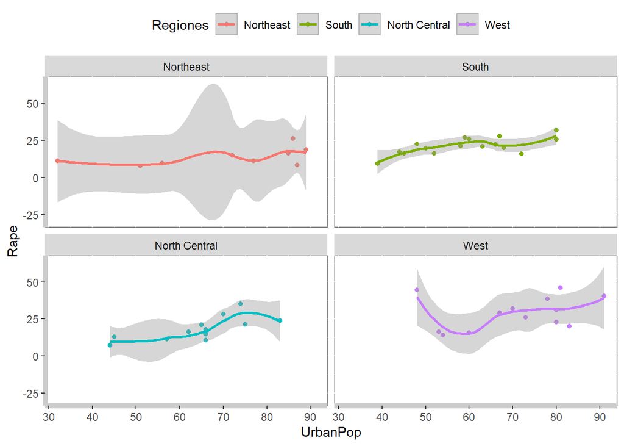

> **x=UrbanPop, y=Assault**

En el siguiente gráfico observamos si existe una cierta relación entre el porcentaje de población urbana y los arrestos por asalto en cada **Región**.

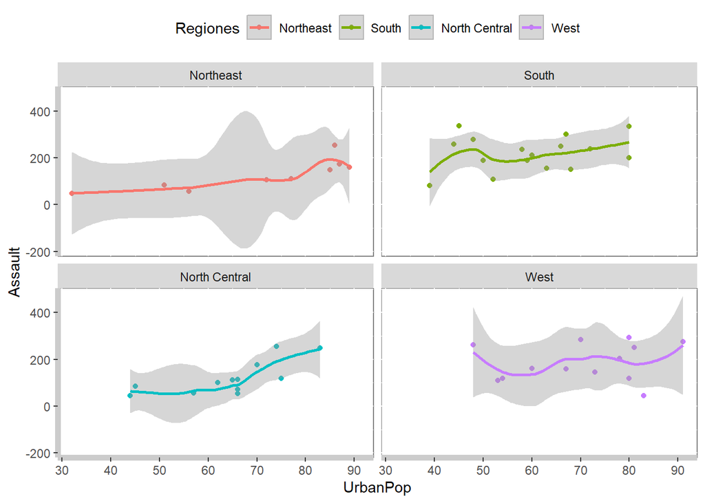